# SA1_Carissa Ying Geok Teng

SA1 Carissa Ying Geok Teng A0205190R

11/2/2021

```r
library("dplyr")
library("lubridate")
```

```r
library("ggplot2")
library("tidyr")
library("ggmap")
library("leaflet")
journeys = read.csv("./Data/journeys.csv")
stations = read.csv("./Data/stations.csv")

head(journeys)
```

```
##   Journey.Duration Journey.ID End.Date End.Month End.Year End.Hour End.Minute
## 1             1320       2351       14         9       17       14         53
## 2              960      11205       15         9       17       16          3
## 3              780      14816       15         9       17       17         38
## 4              720      11403       15         9       17       19         42
## 5             1320      13910       14         9       17        9         46
## 6             1140      10684       19         9       17        8         50
##   End.Station.ID Start.Date Start.Month Start.Year Start.Hour Start.Minute
## 1            514         14           9         17         14           31
## 2            350         15           9         17         15           47
## 3            197         15           9         17         17           25
## 4            201         15           9         17         19           30
## 5            288         14           9         17          9           24
## 6            130         19           9         17          8           31
##   Start.Station.ID
## 1              589
## 2              396
## 3              298
## 4              224
## 5              581
## 6              273
```

```r
head(stations)
```

```
##   Station.ID Capacity                         Station.Name
## 1          1       19           River Street , Clerkenwell
## 2          2       37       Phillimore Gardens, Kensington
## 3          3       32 Christopher Street, Liverpool Street
## 4          4       23      St. Chad's Street, King's Cross
## 5          5       27        Sedding Street, Sloane Square
## 6          6       18       Broadcasting House, Marylebone
##                Location
## 1  (51.529163,-0.10997)
## 2 (51.499606,-0.197574)
## 3 (51.521283,-0.084605)
## 4 (51.530059,-0.120973)
## 5  (51.49313,-0.156876)
## 6 (51.518117,-0.144228)
```

## Q1

```r
journeys = journeys %>% mutate(Start.Time = paste0(Start.Year, "-",
                                                   Start.Month, "-",
                                                   Start.Date, " ",
                                                   Start.Hour, ":",
                                                   Start.Minute, ":"))

journeys$Start.Time = journeys$Start.Time %>%
  parse_date_time(c("$Y-%m-%d %H:%M", "%y-%m-%d %H:%M"))
```

## Q2

```r
# Get the end time
journeys = journeys %>% mutate(End.Time = paste0(End.Year, "-",
                                                   End.Month, "-",
                                                   End.Date, " ",
                                                   End.Hour, ":",
                                                   End.Minute, ":"))

journeys$End.Time = journeys$End.Time %>%
  parse_date_time(c("$Y-%m-%d %H:%M", "%y-%m-%d %H:%M"))

## Idea: if start time is 14min 59s and time taken is 61s, the end time is 16min 00s. It gets recorded as 14min to 16min. The difference here is 120s. Hence the max difference is 1min

# Get the difference in seconds, check if withint +-60s
time.taken = journeys$End.Time - journeys$Start.Time
journeys$Time.Valid = time.taken >= (journeys$Journey.Duration - 60) &
  time.taken <= (journeys$Journey.Duration + 60)

# Check that all are valid
head(journeys[!journeys$Time.Valid, ])
```

```
##  [1] Journey.Duration Journey.ID       End.Date         End.Month
##  [5] End.Year         End.Hour         End.Minute       End.Station.ID
##  [9] Start.Date       Start.Month      Start.Year       Start.Hour
## [13] Start.Minute     Start.Station.ID Start.Time       End.Time
## [17] Time.Valid
## <0 rows> (or 0-length row.names)
```

## Q3

Generally, there is a higher demand for bike sharing on weekdays (Monday to Friday) than on Weekends (Saturday and Sunday). However, it is worth noting that the demand on Wednesday is significantly lower than on other weekdays.

```r
# add all the demand of the same day in the same week
journeys$Start.Week = week(journeys$Start.Time)
journeys$Start.Week.Day = weekdays(journeys$Start.Time)
data = journeys %>% group_by(Start.Week, Start.Week.Day) %>%
  summarise(Demand = n())
```

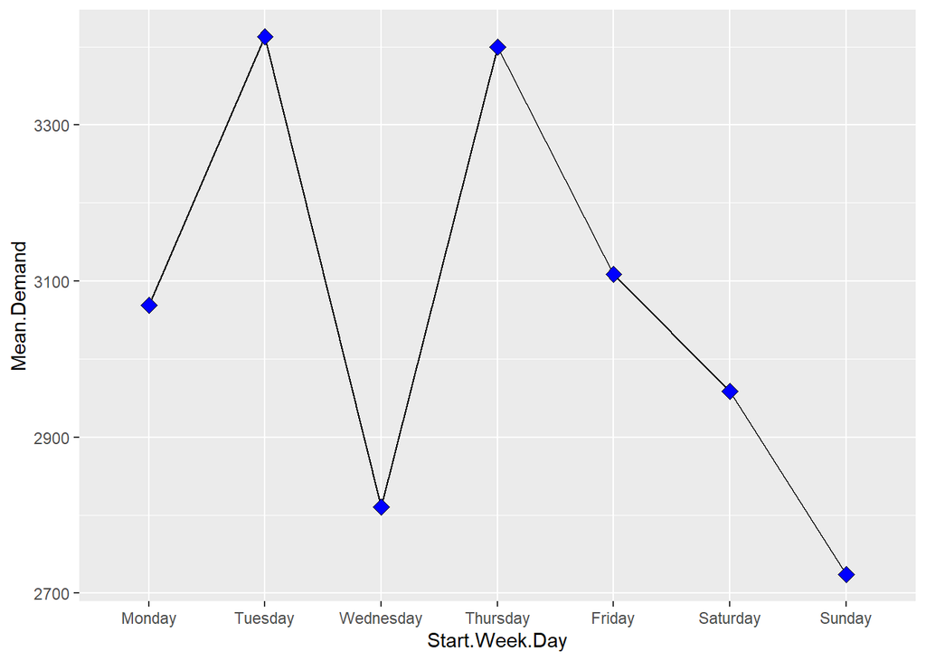

```r
# Average each day's demand
data = data %>% group_by(Start.Week.Day) %>% summarise(Mean.Demand = mean(Demand))

# Reorder data
order = c("Monday", "Tuesday", "Wednesday", "Thursday", "Friday", "Saturday", "Sunday")
data = data %>% slice(match(order, Start.Week.Day))
data$Start.Week.Day <- factor(data$Start.Week.Day, levels=unique(data$Start.Week.Day))

# plot
ggplot(data=data, aes(x=Start.Week.Day, y=Mean.Demand)) +
  geom_line(group=1) +
  geom_point(size=3, shape=23, fill="blue")
```

## Q4

```r
# remove brackets
stations$Location = gsub("\\(|\\)", "", stations$Location)
# split cols
stations = stations %>% separate(Location, c("Latitude", "Longitude"), sep=",")

head(stations)
```

```
##   Station.ID Capacity                         Station.Name  Latitude Longitude
## 1          1       19           River Street , Clerkenwell 51.529163  -0.10997
## 2          2       37       Phillimore Gardens, Kensington 51.499606 -0.197574
## 3          3       32 Christopher Street, Liverpool Street 51.521283 -0.084605
## 4          4       23      St. Chad's Street, King's Cross 51.530059 -0.120973
## 5          5       27        Sedding Street, Sloane Square  51.49313 -0.156876
## 6          6       18       Broadcasting House, Marylebone 51.518117 -0.144228
```

## Q5

### (a)

```r
# get the start minute of the time slot
journeys$Timeslot =  ifelse(journeys$Start.Minute<30, 0, 30)

# get the start hour
journeys$Timeslot = paste0(journeys$Start.Hour, ":", journeys$Timeslot)

# parse
journeys$Timeslot = strptime(journeys$Timeslot, "%H:%M")

# create end time
journeys$Timeslot = paste0(strftime(journeys$Timeslot, "%H:%M"),
                           "-",
                           strftime(journeys$Timeslot + minutes(30), "%H:%M"))

head(journeys)
```

```
##   Journey.Duration Journey.ID End.Date End.Month End.Year End.Hour End.Minute
## 1             1320       2351       14         9       17       14         53
## 2              960      11205       15         9       17       16          3
## 3              780      14816       15         9       17       17         38
## 4              720      11403       15         9       17       19         42
## 5             1320      13910       14         9       17        9         46
## 6             1140      10684       19         9       17        8         50
##   End.Station.ID Start.Date Start.Month Start.Year Start.Hour Start.Minute
## 1            514         14           9         17         14           31
## 2            350         15           9         17         15           47
## 3            197         15           9         17         17           25
## 4            201         15           9         17         19           30
## 5            288         14           9         17          9           24
## 6            130         19           9         17          8           31
##   Start.Station.ID          Start.Time            End.Time Time.Valid
## 1              589 2017-09-14 14:31:00 2017-09-14 14:53:00       TRUE
## 2              396 2017-09-15 15:47:00 2017-09-15 16:03:00       TRUE
## 3              298 2017-09-15 17:25:00 2017-09-15 17:38:00       TRUE
## 4              224 2017-09-15 19:30:00 2017-09-15 19:42:00       TRUE
## 5              581 2017-09-14 09:24:00 2017-09-14 09:46:00       TRUE
## 6              273 2017-09-19 08:31:00 2017-09-19 08:50:00       TRUE
##   Start.Week Start.Week.Day    Timeslot
## 1         37       Thursday 14:30-15:00
## 2         37         Friday 15:30-16:00
## 3         37         Friday 17:00-17:30
## 4         37         Friday 19:30-20:00
## 5         37       Thursday 09:00-09:30
## 6         38        Tuesday 08:30-09:00
```

### (b)

```r
journeys$Is.Weekend = journeys$Start.Week.Day %in% c("Saturday", "Sunday")

head(journeys)
```

```
##   Journey.Duration Journey.ID End.Date End.Month End.Year End.Hour End.Minute
## 1             1320       2351       14         9       17       14         53
## 2              960      11205       15         9       17       16          3
## 3              780      14816       15         9       17       17         38
## 4              720      11403       15         9       17       19         42
## 5             1320      13910       14         9       17        9         46
## 6             1140      10684       19         9       17        8         50
##   End.Station.ID Start.Date Start.Month Start.Year Start.Hour Start.Minute
## 1            514         14           9         17         14           31
## 2            350         15           9         17         15           47
## 3            197         15           9         17         17           25
## 4            201         15           9         17         19           30
## 5            288         14           9         17          9           24
## 6            130         19           9         17          8           31
##   Start.Station.ID          Start.Time            End.Time Time.Valid
## 1              589 2017-09-14 14:31:00 2017-09-14 14:53:00       TRUE
## 2              396 2017-09-15 15:47:00 2017-09-15 16:03:00       TRUE
## 3              298 2017-09-15 17:25:00 2017-09-15 17:38:00       TRUE
## 4              224 2017-09-15 19:30:00 2017-09-15 19:42:00       TRUE
## 5              581 2017-09-14 09:24:00 2017-09-14 09:46:00       TRUE
## 6              273 2017-09-19 08:31:00 2017-09-19 08:50:00       TRUE
##   Start.Week Start.Week.Day    Timeslot Is.Weekend
## 1         37       Thursday 14:30-15:00      FALSE
## 2         37         Friday 15:30-16:00      FALSE
## 3         37         Friday 17:00-17:30      FALSE
## 4         37         Friday 19:30-20:00      FALSE
## 5         37       Thursday 09:00-09:30      FALSE
## 6         38        Tuesday 08:30-09:00      FALSE
```

### (c)

The weekend plot, on the other hand, shows a low demand in the early morning and late night and higher demand in the middle of the day, which is what we would expect from leisurely use.

```r
# Get the demand for each day
data = journeys %>% group_by(as.Date(Start.Time), Timeslot) %>%
  summarise(Is.Weekend = all(Is.Weekend), Demand = n())
# Get the average demand for weekday/end
data = data %>% group_by(Is.Weekend, Timeslot) %>%
  summarise(Mean.Demand = mean(Demand))
```

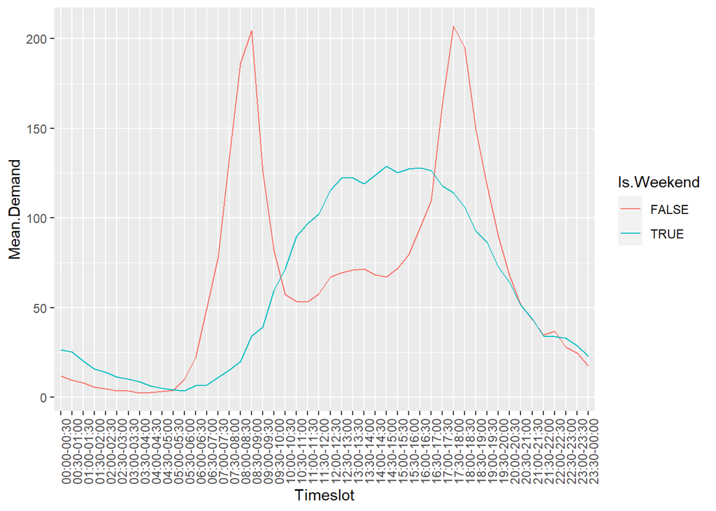

```r
# Plot
ggplot(data=data, aes(x=Timeslot, y=Mean.Demand, group=Is.Weekend, color=Is.Weekend)) +
  geom_line() +
  theme(axis.text.x = element_text(angle=90))
```

## Q6

The current planned capacity does not seem to account for the station’s crowd. Otherwise, we would see a generally increasing trend. Hence an improvement can be made in the plans to assign higher capacities where there is a greater demand.

```r
# Get daily demand
data = journeys %>% group_by(as.Date(Start.Time), Start.Station.ID) %>%
  summarise(Station.Crowd = n())
```

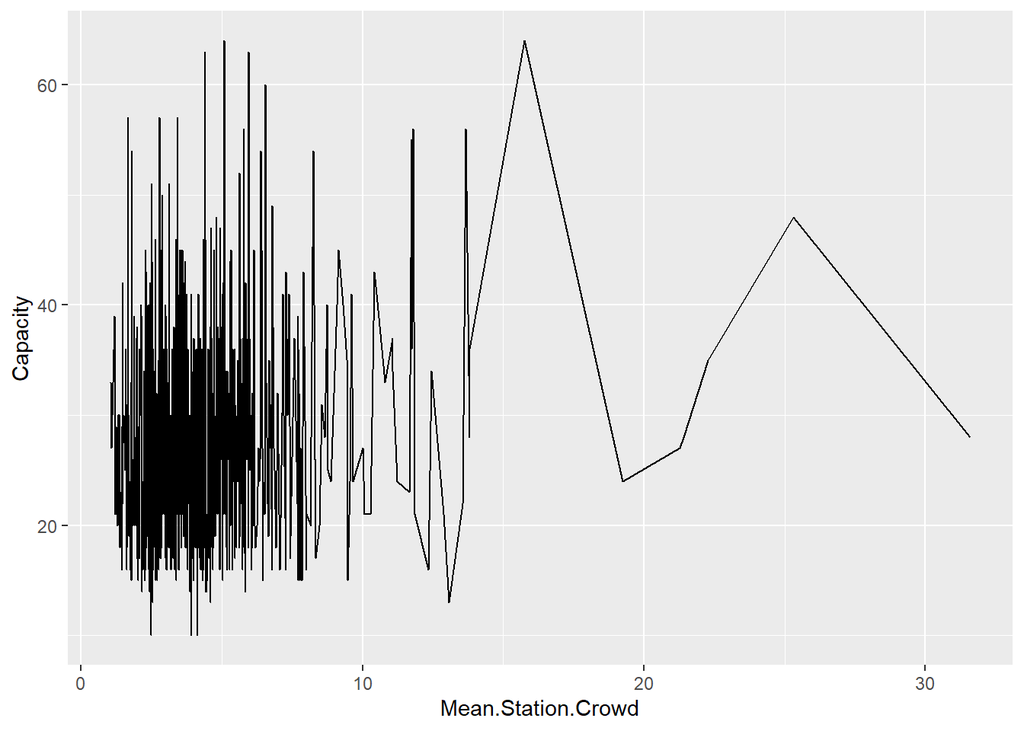

```r
# Get average crowd per station
data = data %>% group_by(Start.Station.ID) %>%
  summarise(Mean.Station.Crowd = mean(Station.Crowd))

# Merge to get capacity
data = merge(data, stations[c("Station.ID", "Capacity")],
             by.x="Start.Station.ID", by.y="Station.ID")

# Plot
ggplot(data=data, aes(x=Mean.Station.Crowd, y=Capacity)) +
  geom_line(group=1)
```

## Q7

```r
# Filter for weekdays
data = journeys[!journeys$Is.Weekend,]

# Get the busiest starting stations
busiest.start = journeys %>% group_by(as.Date(Start.Time), Start.Station.ID) %>%
  summarise(Demand = n())
busiest.start = busiest.start %>% group_by(Start.Station.ID) %>%
  summarise(Mean.Demand = mean(Demand))
busiest.start = busiest.start[order(busiest.start$Mean.Demand, decreasing=T), ]
busiest.start = busiest.start[1:10, ]
busiest.start$Busiest.Start = TRUE

# Get the busiest end
busiest.end = journeys %>% group_by(as.Date(End.Time), End.Station.ID) %>%
  summarise(Demand = n())
busiest.end = busiest.end %>% group_by(End.Station.ID) %>%
  summarise(Mean.Demand = mean(Demand))
busiest.end = busiest.end[order(busiest.end$Mean.Demand, decreasing=T), ]
busiest.end = busiest.end[1:10, ]
busiest.end$Busiest.End = TRUE

# join
busiest = merge(busiest.start, busiest.end,
                by.x=c("Start.Station.ID", "Mean.Demand"),
                by.y=c("End.Station.ID", "Mean.Demand"), all=T)

head(busiest)
```

```
##   Start.Station.ID Mean.Demand Busiest.Start Busiest.End
## 1               14    25.30000          TRUE          NA
## 2               14    25.36000            NA        TRUE
## 3               66    15.26000            NA        TRUE
## 4              111    13.79167          TRUE          NA
## 5              154    22.27083          TRUE          NA
## 6              154    23.06667            NA        TRUE
```